# Lab 3: Probability distribution and sampling

Carlo Gaetan

# Probability distributions in R

Because it is a statistical language, there are a large number of probability distributions in R by default and an even larger number that can be loaded from packages. The table below gives a listing of the most common distributions in R, the name of the function within R, and the parameters of the distribution

## Common distributions

| Distribution | R name | Parameters |
| --- | --- | --- |
| beta | beta | shape1, shape2, ncp |
| Binomial | binom | size, prob |
| Cauchy | cauchy | location, scale |
| chi-squared | chisq | df, ncp |
| exponential | exp | rate |
| F | f | df1, df2, ncp |
| gamma | gamma | shape, scale |
| geometric | geom | prob |
| hypergeometric | hyper | m, n, k |
| log-normal | lnorm | meanlog, sdlog |
| logistic | logis | location, scale |
| Negative binomial | nbinom | size, prob |
| normal | norm | mean, sd |
| Poisson | pois | lambda |
| Student’s t | t | df, ncp |
| uniform | unif | min, max |
| Weibull | weibull | shape, scale |
| Wilcoxon | wilcox | m, n |

R actually provides four related functions for each probability distribution. These functions are called by adding a letter at the beginning of the function name. The variants of each probability distribution are:

- “d” = density: probability density function (PDF)
- “p” = cumulative distribution function (CDF)
- “q” = quantile: calculates the value associated with a specified tail probability, inverse of “p”
- “r” = random: simulates random numbers

The first argument to these functions is the same regardless of the distribution and is the value *x* for “d”, the quantile *q* for “p”, the probability *p* for “q”, and the sample size *n* for “r”

# Example with Binomial distribution

The binomial arises naturally from counts of the number of successes given a probability of success, p, and a sample size, n.

```r
prob<-0.3
size<-10 # the 'n' in the slide's formula
dbinom(3,size=size,prob = prob)
```

```
## [1] 0.2668279
```

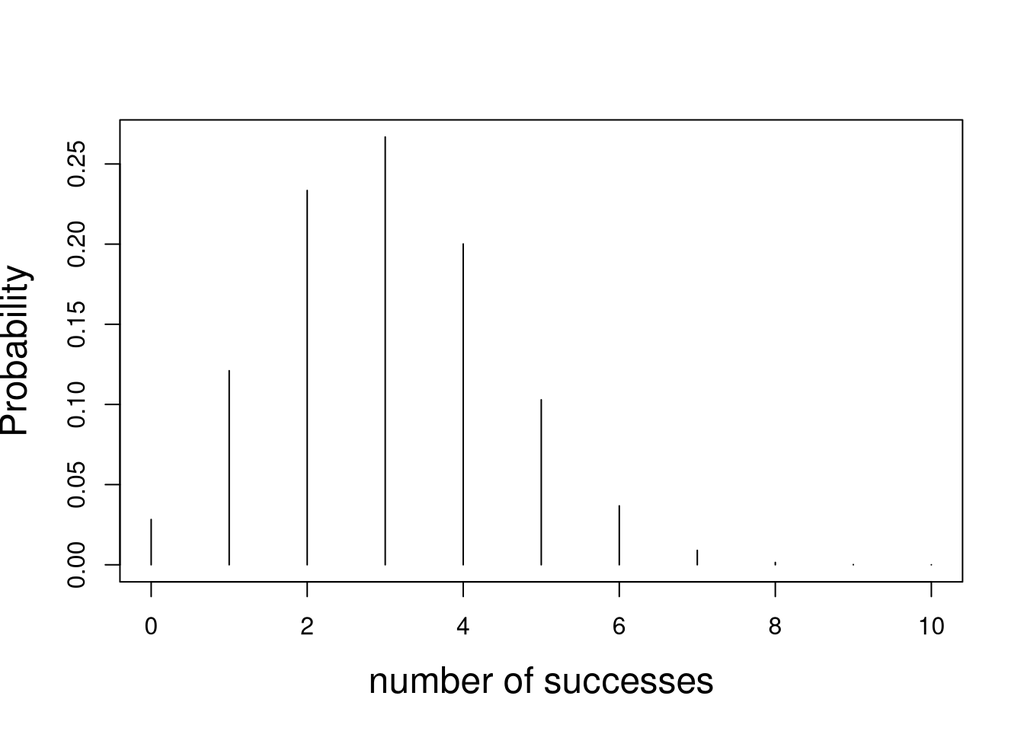

```r
x<-0:size
p<-dbinom(x,size=size,prob = prob)
plot(x,p,type='h',ylab="Probability",xlab="number of successes",cex.lab=1.5)
```

```r
pbinom(3,size=size,prob = prob)
```

```
## [1] 0.6496107
```

```r
sum(dbinom(0:3,size=size,prob = prob))
```

```
## [1] 0.6496107
```

```r
p<-pbinom(3,size=size,prob = prob)
qbinom(p,size=size,prob = prob)
```

```
## [1] 3
```

# Simulation from a distribution

Computer are deterministic machines and thus they cannot produce random samples In fact, `rbinom()` draws a **pseudorandom** sequence that looks like a random sequence from a Binomial distribution, although it is not ``Looks like a random sequence’’ means that the sequence is tested to check whether it is possible to predict its future values.

## Pseudo-Random Number Generator

1. Accept some initial input number, that is a seed.
2. Apply that seed in a sequence of mathematical operations to generate the result. That result is the random number.
3. Use that resulting random number as the seed for the next iteration.
4. Repeat the process to emulate randomness.

Now let’s look at an example.

## The Linear Congruential Generator

This generator produces a series of pseudorandom numbers. Given an initial seed $X_0$ and integer parameters $a$ as the multiplier, $b$ as the increment, and $m$ as the modulus, the generator is defined by the linear relation:
$$X_n =
(aX_{n-1} + b) mod\, m$$
.

Each of these members have to satisfy the following conditions:

$m > 0$ (the modulus is positive),

$0 < a < m$ (the multiplier is positive but less than the modulus),

$0 \le b < m$ (the increment is non negative but less than the modulus),

$0 \le X_0 < m$ (the seed is non negative but less than the modulus).

In computing and mathematics, the *modulo operation* returns the remainder or signed remainder of a division, after one number is divided by another, the latter being called the modulus of the operation.

Given two positive numbers a and n, $a$ modulo $n$ (often abbreviated as $a\, mod\, n$) is the remainder of the Euclidean division of $a$ by $n$, where $a$ is the dividend and $n$ is the divisor.

```r
a<-8.3
n<-3.1
a%%n
```

```
## [1] 2.1
```

```r
mygen<-function(x,m,a,b) {
 (a *x + b) %% m
}

x0<-4
m<-100
a<-3
b<-5
x1<-mygen(x0,m,a,b)
x1
```

```
## [1] 17
```

```r
x2<-mygen(x1,m,a,b)
x2
```

```
## [1] 56
```

```r
x3<-mygen(x2,m,a,b)
x3
```

```
## [1] 73
```

```r
x4<-mygen(x3,m,a,b)
x4
```

```
## [1] 24
```

Pseudorandom sequences start from a certain **seed**. If we choose the same seed, then we have the same sequence.

In R the seed of the pseudo random sequence is set by command `set.seed(x)` where `x` is a number

```r
set.seed(54)
rbinom(1,size=size,prob = prob)
```

```
## [1] 6
```

```r
set.seed(54)
rbinom(1,size=size,prob = prob)
```

```
## [1] 6
```

```r
set.seed(54)
rbinom(1,size=size,prob = prob)
```

```
## [1] 6
```

```r
rbinom(1,size=size,prob = prob)
```

```
## [1] 4
```

```r
rbinom(1,size=size,prob = prob)
```

```
## [1] 4
```

```r
set.seed(54)
rbinom(3,size=size,prob = prob)
```

```
## [1] 6 4 4
```

# Comparison of the distributions

## Bar charts

Simulation of 1000 values, their bar charts and the true probability function (`dbinom`, `rbinom`)

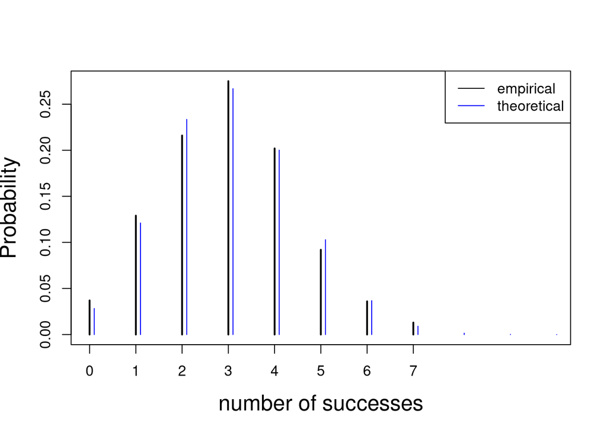

```r
n<-1000
y<-rbinom(n,size=size,prob = prob)
freq<-table(y) # frequencies
relfreq<-freq/n # relative frequencies
plot(table(y)/n,xlim=c(0,size),ylab="Probability",xlab="number of successes",cex.lab=1.5)
x<-0:size
p<-dbinom(x,size=size,prob = prob) # probabilities
eps<-0.1 # expand the x values
lines(x+eps,p,col="blue","h")
legend("topright",legend=c("empirical","theoretical"),  lty=c(1,1),col=c("black","blue"))
```

## Cumulative distribution function

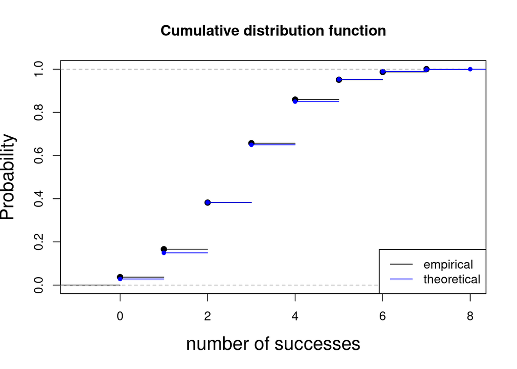

```r
plot(ecdf(y),ylab="Probability",
xlab="number of successes",cex.lab=1.5,main="Cumulative distribution function")
p<-pbinom(x,size=size,prob = prob)
points(x,p,pch=20,col="blue")
segments(x,p,c(x[-1],size+1),p,col="blue")
legend("bottomright",  legend=c("empirical","theoretical"),
  lty=c(1,1),col=c("black","blue"))
```

## QQ-plot

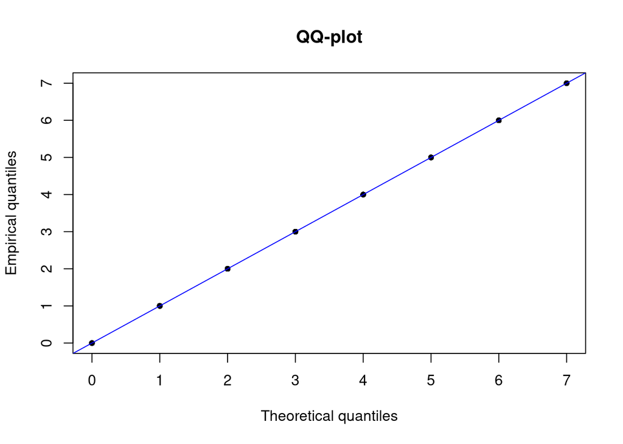

```r
r<-rank(y)
p<-(r-0.5)/n
q<-qbinom(p,size = size, prob =prob)
plot(q,y,xlab="Theoretical quantiles", ylab="Empirical quantiles",main="QQ-plot",pch=20)
abline(a=0,b=1, col="blue")
```

### Lab questions

Consider a binomial distribution that has a constant mean, $np$. What are the differences in the shape of this distribution if it has a high $n$ and low p vs. a low $n$ and high $p$?

## Example with Poisson distribution

The Poisson is also very common for count data and arises as the number of events that occur in a fixed amount of time (e.g. number of bird sightings per hour), or the number of items found in a fixed amount of space (e.g. the number of trees in a plot). Unlike the Binomial distribution the Poisson doesn’t have a fixed upper bound for the number of events that can occur.

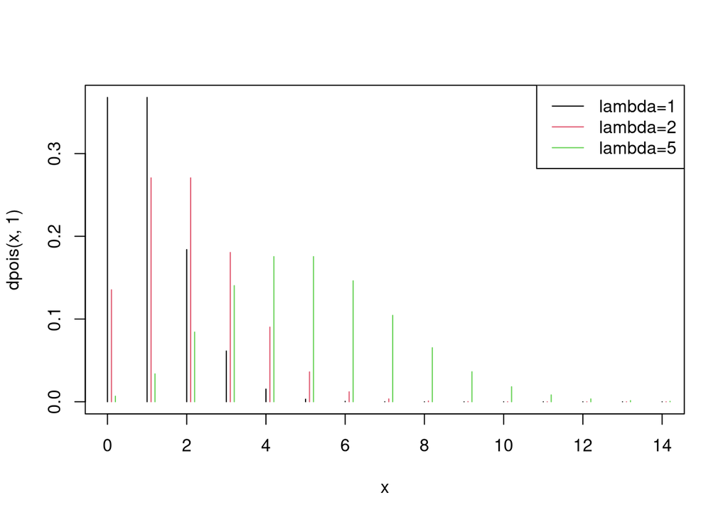

```r
x <- 0:14
plot(x,dpois(x,1),type='h')
lines(x+0.1,dpois(x,2),type='h',col=2)
lines(x+0.2,dpois(x,5),type='h',col=3)
legend("topright",legend=c("lambda=1","lambda=2","lambda=5"),lty=1,col=1:3)
```

## Example with Gaussian distribution

```r
mu<-10
sigma<-2
dnorm(1,mean= mu, sd =sigma)
```

```
## [1] 7.991871e-06
```

```r
qnorm(0.5,mean= mu, sd =sigma)
```

```
## [1] 10
```

```r
pnorm(10,mean= mu, sd =sigma)
```

```
## [1] 0.5
```

```r
rnorm(n=1,mean=2,sd =4)
```

```
## [1] -2.081567
```

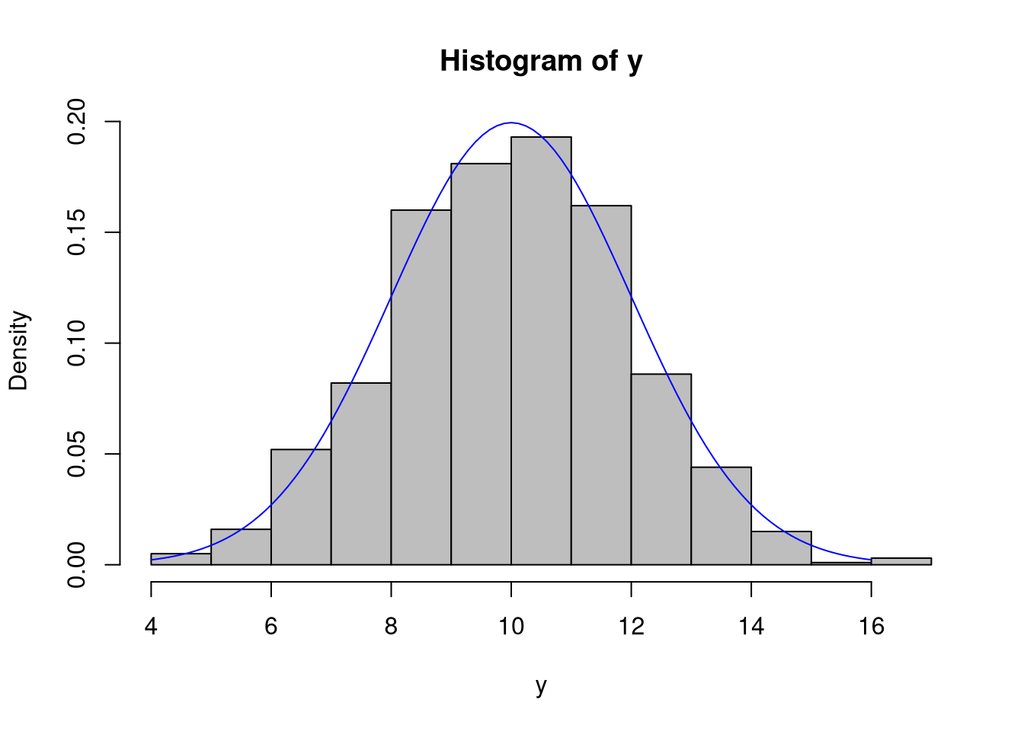

```r
n<-1000
y<-rnorm(n=n, mean=mu, sd=sigma)
hist(y,freq=FALSE,col="gray")
curve(dnorm(x,mean=mu, sd=sigma), from=(mu-3*sigma), to=(mu+3*sigma), add=TRUE, col="blue")
```

Comparing theoretical CDF with the empirical one (`pnorm`)

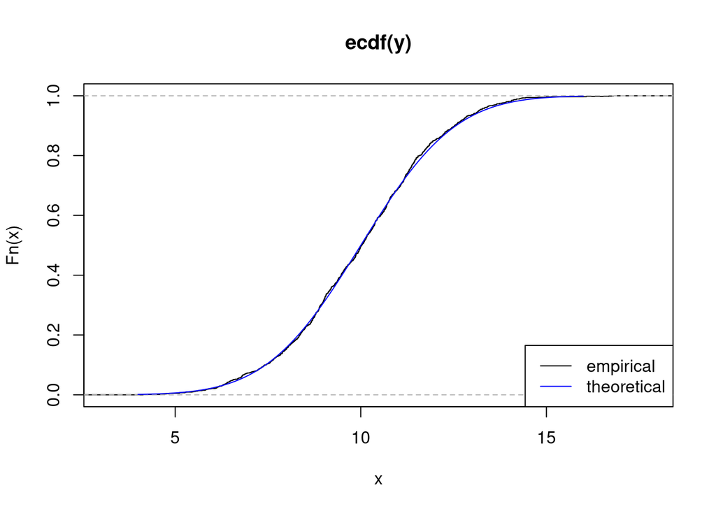

```r
plot(ecdf(y))
curve(pnorm(x,mean=mu, sd=sigma),   from=(mu-3*sigma),
    to=(mu+3*sigma), add=TRUE,col="blue")
legend("bottomright", legend=c("empirical","theoretical"),
  lty=c(1,1),col=c("black","blue"))
```

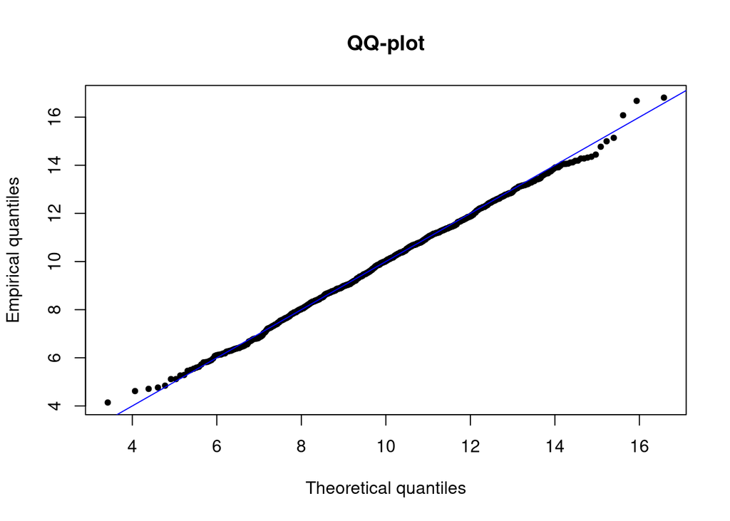

```r
r<-rank(y)
p<-(r-0.5)/n
q<-qnorm(p,mean=mu, sd=sigma)
plot(q,y,xlab="Theoretical quantiles",ylab="Empirical quantiles",main="QQ-plot",pch=20)
abline(a=0,b=1, col="blue")
```

# Approximating a distribution of discrete random variable

The next two plots depict a comparison of the Poisson, Normal, and Binomial with the same mean and a large sample size. The Poisson and Binomial are identical in the two figures but in the first the normal has the same variance as the Poisson and the second it is the same as the binomial.

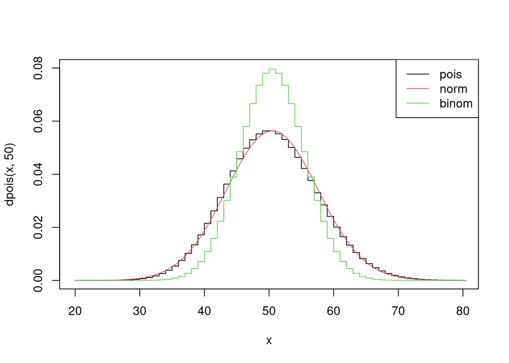

```r
x <- 20:80
plot(x,dpois(x,50),type='s',ylim=c(0,0.08))     #Poisson with mean 50 (variance = 50)
lines(x+0.5,dnorm(x,50,sqrt(50)),col=2)     #Normal with mean and variance of 50
lines(x,dbinom(x,100,0.5),col=3,type='s')       #Binomial with mean 50 (variance = 25)
legend("topright",legend=c("pois","norm","binom"),col=1:3,lty=1)
```

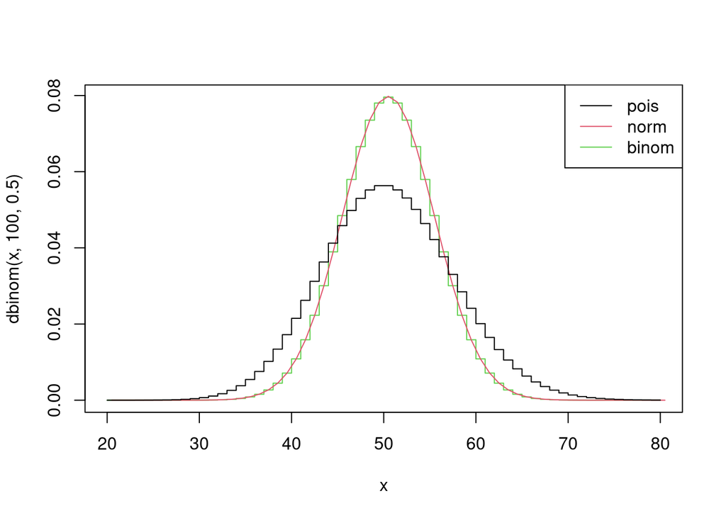

```r
plot(x,dbinom(x,100,0.5),type='s',col=3)    #Binomial with mean 50 (variance = 25)
lines(x+0.5,dnorm(x,50,sqrt(25)),col=2)     #Normal with mean 50 and variance of 25
lines(x,dpois(x,50),col=1,type='s')           #Poisson with mean 50 (variance = 50)
legend("topright",legend=c("pois","norm","binom"),col=1:3,lty=1)
```

# Random samples

In many practical contexts it is not possible to observe all possible value of a population (climate). A random sample is chosen from the population by a selection procedure with an unpredictable component. If samples are random, then **inferential statistical methods** based on the **theory of probability** can be used to infer about the unobserved population the samples come from.

## Sampling in R

Function `sample()` takes a random sample from a given population without replacement (default choice)

```r
set.seed(10)
data <- 1:10
sample(data, size=5)
```

```
## [1] 9 7 8 6 3
```

```r
sample(data, size=5)
```

```
## [1]  8  7  2 10  5
```

with replacement

```r
sample(data, size=5,replace=TRUE)
```

```
## [1] 8 7 6 7 6
```

## Sampling variability

We consider the hourly measurements of air pollutant concentrations, wind speed and wind direction collected at the Marylebone (London) air quality monitoring supersite between 1st January 1998 and 23rd June 2005.

```r
london<-read.csv("openair.csv")
```

In particular the wind speed (`ws`). It contains some missing values

```r
summary(london$ws)
```

```
##    Min. 1st Qu.  Median    Mean 3rd Qu.    Max.    NA's
##   0.000   2.600   4.100   4.489   5.760  20.160     632
```

We omit the missing data

```r
y<-as.numeric(na.omit(london$ws))
```

Suppose that these data represents the whole population. In such case the mean of the population (the expected value) is

```r
mu<-mean(y)
mu
```

```
## [1] 4.488703
```

Suppose that, for some reason, we cannot observe all the data but only a random sample of size $100$ (`size=100`). We want to use this sample to estimate the true average level

```r
n<-100
mean(sample(y, size=n,replace = TRUE))
```

```
## [1] 4.521893
```

If we repeat the experiment twice

```r
mean(sample(y, size=n,replace = TRUE))
```

```
## [1] 3.876084
```

```r
mean(sample(y, size=n,replace = TRUE))
```

```
## [1] 4.402453
```

we see that the estimates based on random samples fluctuate around the true value.

To get more insight into random sampling, we can repeat the sampling process a large number of times, say 10,000 times.

```r
all.sim <- replicate(10000, sample(y, size=n,replace = TRUE))
```

Object `all.sim` is a matrix with 100 rows and 10000 columns

```r
dim(all.sim)
```

```
## [1]   100 10000
```

We have

```r
est <- apply(all.sim, 2, mean)
est[1:5]
```

```
## [1] 4.555072 4.541216 3.996399 4.387075 4.327188
```

The histogram of the 10,000 estimates gives us an idea of the distribution of the estimates. The vertical blue line corresponds to the true value of the expectation.

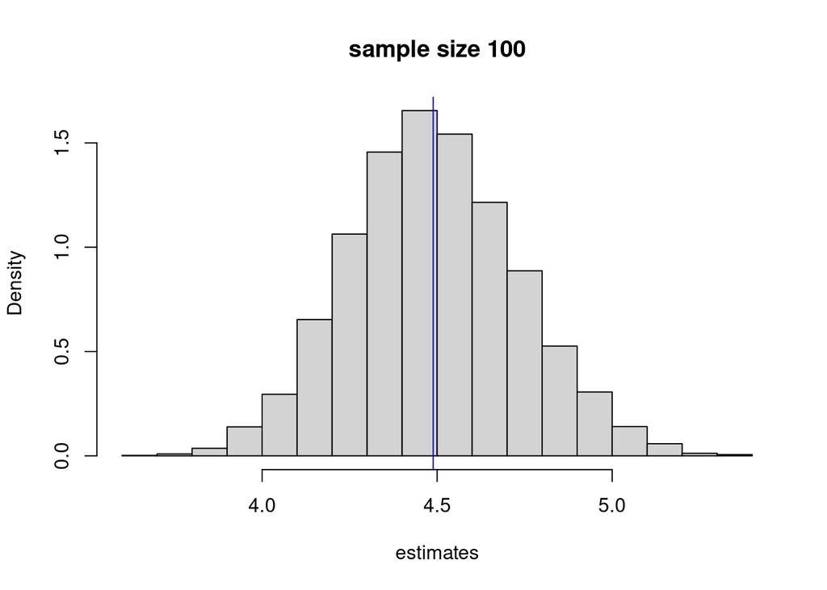

```r
hist(est, freq=FALSE, main="sample size 100", xlab="estimates")
abline(v=mu, col="blue")
```

The distribution of the estimates is centered around the true value and looks symmetric

```r
summary(est)
```

```
##    Min. 1st Qu.  Median    Mean 3rd Qu.    Max.
##   3.643   4.322   4.481   4.490   4.649   5.330
```

```r
mu
```

```
## [1] 4.488703
```

The $90\%$ of the estimates with samples size $100$ lies in

```r
 quantile(est, probs=c(0.05, 0.95))
```

```
##       5%      95%
## 4.102518 4.905680
```

The distribution of the sampling error in the estimation is as follows

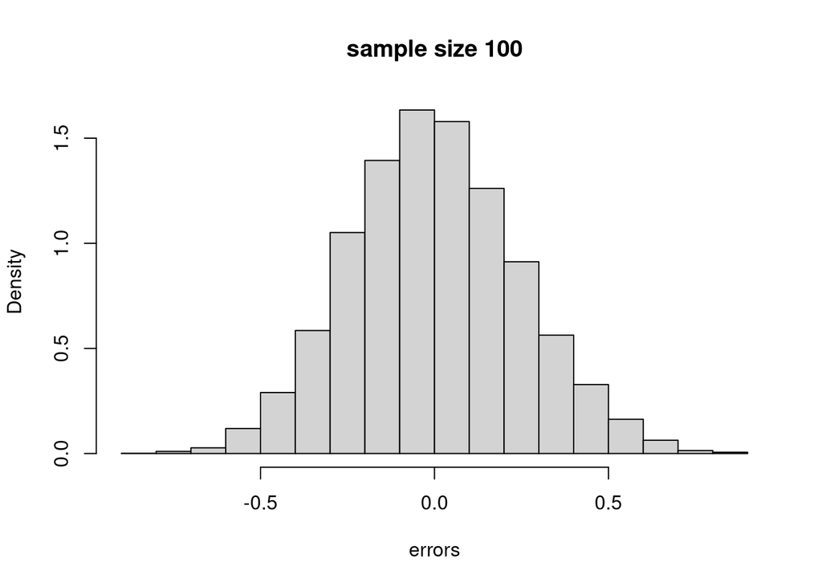

```r
errors<-est-mu
hist(errors,freq=FALSE, main="sample size 100")
```

the bias

```r
bias<-mean(est)-mu
bias
```

```
## [1] 0.0009503136
```

the variance

```r
v<-mean(est^2)-mean(est)^2
v
```

```
## [1] 0.05891145
```

the standard deviation

```r
s<-sqrt(v)
s
```

```
## [1] 0.2427168
```

If the sample size is larger (the double), then the sample distribution of the estimates is more concentrated around the true value

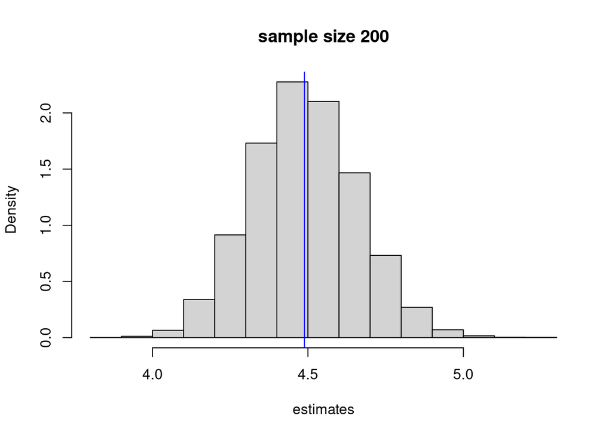

```r
n<-2*n
all.sim2 <- replicate(10000, sample(y, size=n,replace = TRUE))
est2 <- apply(all.sim2, 2, mean)
hist(est2, freq=FALSE, main="sample size 200", xlab="estimates")
abline(v=mu, col="blue")
```

The 90% of the estimates with samples size $200$ lies in

```r
quantile(est2, probs=c(0.05, 0.95))
```

```
##       5%      95%
## 4.211123 4.774781
```

i.e. the interval with samples of size $200$ is shorter

With samples of size 1,000

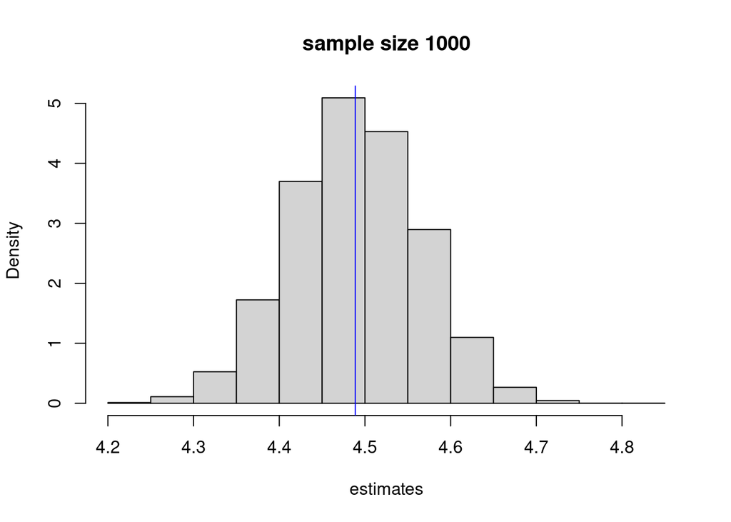

```r
n<-1000
all.sim3 <- replicate(10000, sample(y, size=n,replace = TRUE))
est3 <- apply(all.sim3, 2, mean)
hist(est3, freq=FALSE, main="sample size 1000", xlab="estimates")
abline(v=mu, col="blue")
```

the interval becomes even shorter

```r
quantile(est3, probs=c(0.05, 0.95))
```

```
##       5%      95%
## 4.366210 4.612704
```

# The central limit theorem

Increasing number of random samples of size $10$

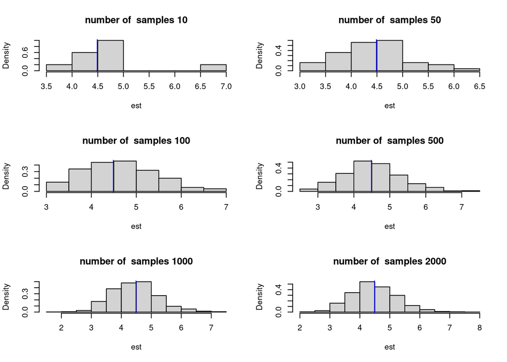

```r
par(mfrow=c(3,2))
for(i in c(10, 50, 100, 500, 1000, 2000)){
    all.sim <- replicate(i, sample(y, size=10,replace = TRUE))
    est <- apply(all.sim, 2, mean)
    hist(est, freq=FALSE, main=paste("number of  samples", i))
abline(v=mu, col="blue")
}
```

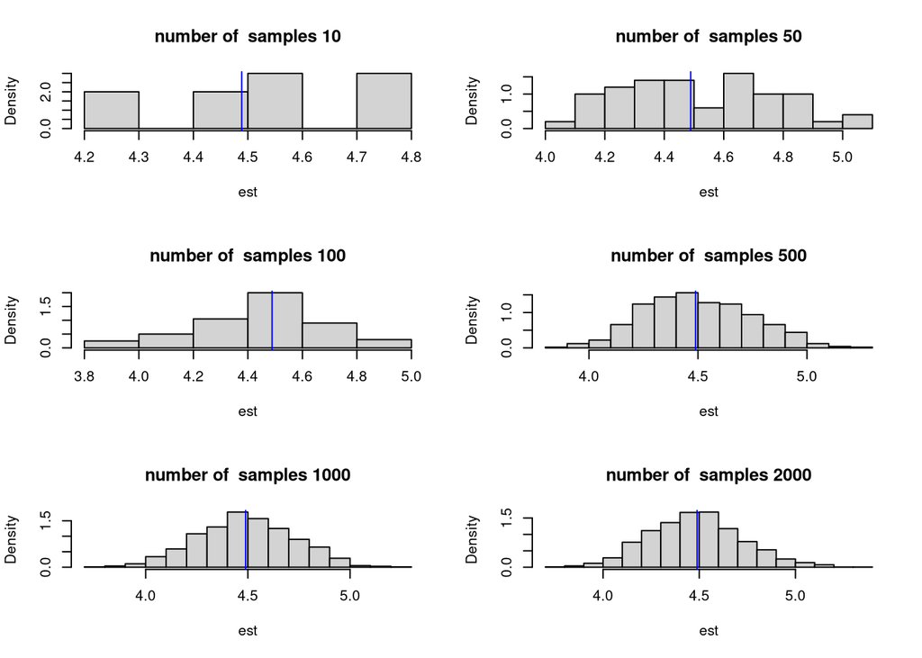

```r
par(mfrow=c(3,2))
set.seed(1)
for(i in c(10, 50, 100, 500, 1000, 2000)){
    all.sim <- replicate(i, sample(y, size=100,replace = TRUE))
    est <- apply(all.sim, 2, mean)
    hist(est, freq=FALSE, main=paste("number of  samples", i))
abline(v=mu, col="blue")
}
```

An example using QQ-plots

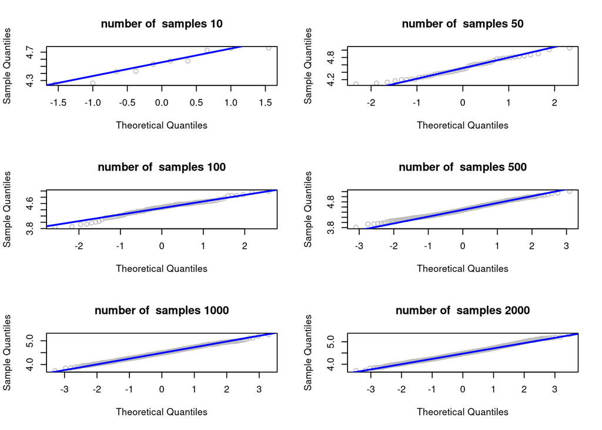

```r
par(mfrow=c(3,2))
set.seed(1)
for(i in c(10, 50, 100, 500, 1000, 2000)){
    all.sim <- replicate(i, sample(y, size=100,replace = TRUE))
    est <- apply(all.sim, 2, mean)
    qqnorm(est,  main=paste("number of  samples", i),col="gray")
    qqline(est,col="blue",lwd=2)
}
```